# Liens entre la recherche du FNS et les objectifs de développement durable de l’ONU

13.04.2023

**Dans le cadre d’une analyse exploratoire, le FNS a examiné dans quelle mesure les projets qu’il encourage présentent un rapport avec les objectifs de développement durable des Nations unies. L’analyse a montré que des liens avec ces objectifs peuvent être trouvés dans l’ensemble des domaines de recherche. Une enquête menée auprès de chercheurs et chercheuses doit maintenant fournir davantage d’informations sur le sujet.**

Les dix-sept objectifs de développement durable (ODD) des Nations unies visent à promouvoir le bien-être de toutes et tous, partout dans le monde, de manière équitable, et en protégeant le système naturel. La recherche revêt un rôle clé à cet égard : source de nouvelles connaissances, elle jette les bases de l’innovation technologique et sociale, contribuant ainsi au discours politique et social sur le développement d’actions communes et le changement de mentalité.

Au moyen de deux outils de classification, nous avons procédé à une analyse exploratoire visant à déterminer l’étendue du rapport que les projets soutenus par le FNS entretiennent avec les objectifs de développement durable. Bien que ces outils peuvent encore être améliorés (voir l’encadré « La méthode appliquée et ses limites » ci-après), les résultats qu’ils livrent permettent de se faire une première idée des travaux de recherche sur les ODD encouragés par le FNS.

### La méthode appliquée et ses limites

Pour cette analyse, nous avons étudié divers outils de classification des ODD : le classificateur d’ODD développé par Dimensions ainsi que les systèmes d’étiquetage de texte disponibles par le biais du [package R](https://www.r-project.org/about.html) [text2dsg](https://github.com/dwulff/text2sdg#readme) (Aurora, Elsevier, OSDG, SDSN et SIRIS) accessibles au public. Les titres, résumés et mots-clés des projets approuvés ont été soumis à chacun de ces systèmes pour analyse. Nous avons ensuite évalué manuellement un échantillon aléatoire des résultats obtenus avec les divers outils. Pour ce faire, nous avons commencé par relever les ODD qui, selon nous, étaient abordés dans les projets approuvés, puis avons comparé notre estimation avec les résultats délivrés par les outils. En procédant de la sorte, nous avons pu identifier les outils dont les conclusions coïncidaient avec les nôtres et dont les résultats comprenaient le moins de « faux positifs ». On entend par faux positif un cas dans lequel l’outil de classification établit un lien qui s’avère inexistant entre un projet approuvé et un ODD. Notre constats : sur la base des données du FNS, ce sont les outils de Dimensions et d’Elsevier qui se sont montrés les plus fiables. Les approches de chacun d’entre eux sont brièvement expliquées ci-après.

Dimensions  
Le classificateur de Dimensions a été développé par Digital Science ; il repose sur l’apprentissage automatique. Associée à [Dimensions](https://www.dimensions.ai/), le gestionnaire de la plus grande plateforme de données structurées issues de la recherche (publications, subventions, données de recherche, etc.), [Digital Science](https://digitalscience.figshare.com/ndownloader/files/22574228) a créé, sur base des dix-sept ODD, un modèle construit à l’aide d’un volume considérable de requêtes de recherche ciblées. Celui-ci a permis de générer dix-sept jeux de données d’entraînement (un pour chaque ODD) composés de publications issues de la base de données Dimensions et, à l’aide d’outils de traitement du langage, de concevoir un système de classification des ODD. Afin d’améliorer la qualité des jeux de données d’entraînement, des vérifications visant à s’assurer que les publications identifiées correspondent bien à la description de la définition des ODD ont été effectuées régulièrement. Dans certains de ses critères de recherche, le classificateur Dimensions intègre également la recherche par proximité (*Proximity Search*, en anglais), fonction grâce à laquelle des phrases contenant des mots apparentés spécifiques sont également repérées.[^1]

Elsevier  
Chez Elsevier, l’équipe spécialisée dans la science des données a élaboré des [critères pour la recherche de travaux liés aux ODD](https://elsevier.digitalcommonsdata.com/datasets/87txkw7khs/1). Ceux-ci reposent sur [Scopus](https://www.scopus.com/), la base de données bibliographique sur la littérature scientifique d’Elsevier. En collaboration avec des expert·es des domaines concernés, un premier ensemble de critères de recherche sur Scopus a été développé pour chaque ODD. Une première sélection d’écrits scientifiques qui étayent les ODD a ainsi pu être établie. Le processus d’affinement des critères de recherche de travaux liés aux ODD est toutefois toujours en cours. En outre, Elsevier tient compte des commentaires de ses clients pour affiner les critères de recherche utilisés pour chaque ODD. Dans une version plus récente introduite en 2021/2022, un modèle d’apprentissage automatique est venu compléter les algorithmes de recherche. Les analyses effectuées dans le cadre de ce récit de données reposent cependant sur la version originale de 2019. L’outil d’étiquetage de texte proposé par Elsevier n’inclut pas l’ODD 17 (Partenariats pour la réalisation des objectifs). Comme nous ne comptabilisons que les projets approuvés associés à un même ODD par chacun des deux outils de classification (voir la description de l’approche dans la section suivante), cet ODD n’est pas pris en compte dans notre analyse.

**Restrictions**  
À l’heure actuelle, l’identification de liens avec les ODD au moyen d’outils de classification automatique connaît encore des limites : il peut ainsi arriver que des liens existants avec les ODD soient ignorés, ou – au contraire – que des liens « imaginaires » soient identifiés. Ce n’est pas tout : les outils tendent à favoriser un ou plusieurs ODD et à en surestimer la fréquence. De plus, en raison du nombre restreint de jeux de données de validation actuellement disponibles, il est difficile de se prononcer de manière définitive sur la fiabilité des outils de classification.[^2]  
Pour ces raisons, nous avons opté pour approche prudente : nous avons comparé les résultats produits par Dimensions et par Elsevier et n’avons considéré l’existence d’un lien avec un ODD que lorsque les deux outils de classification identifiaient ce lien. Le but de cette approche était d’aboutir à un seuil inférieur adéquat, permettant, à terme, de dégager des tendances et de limiter les faux positifs. Si les méthodes et les mesures sont expérimentales, nous sommes malgré tout convaincus de leur intérêt : elles poursuivent le même objectif, reposent sur des approches similaires et livrent des résultats comparables.  
Entre-temps, les auteur·es du package R text2sdg ont développé une méthode d’assemblage de modèles (technique dite de « [Ensemble-Tool](https://arxiv.org/pdf/2301.11353.pdf) ») regroupant différents outils de classification. Utiliser cette approche plutôt que la nôtre pourrait fournir des résultats d’une fiabilité accrue. Nous nous en réjouissons et suivrons de près les développements dans ce domaine.

Comparaison des deux outils de classification : proportion de projets approuvés de 2016 à 2021 présentant un lien avec un ODD

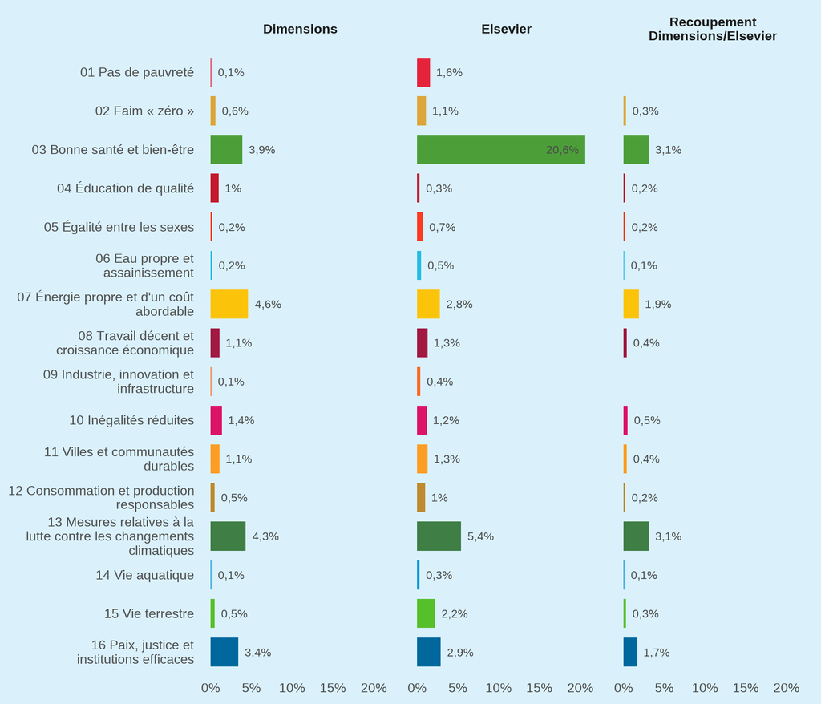

Données : projets approuvés de 2016 à 2021.

### Des recherches sur les objectifs de développement durable dans tous les domaines

Au total, l’approche retenue a établi un lien avec un ou plusieurs ODD pour 1489 des 12’431 projets approuvés depuis 2016, ce qui correspond à 12 % (voir la figure ci-dessous). Les projets approuvés en question ont été soutenus à hauteur de 709 millions de francs, ce qui équivaut à 13 % des fonds accordés. Les liens établis avec plus d’un ODD sont rares : 70 projets approuvés (0,6 %) présentaient un rapport avec deux ODD, tandis que seuls deux projets approuvés étaient liés à trois ODD.

Projets approuvés de 2016 à 2021 pour lesquels un lien avec un ou plusieurs ODD a été établi (part des projets et part du montant accordé)

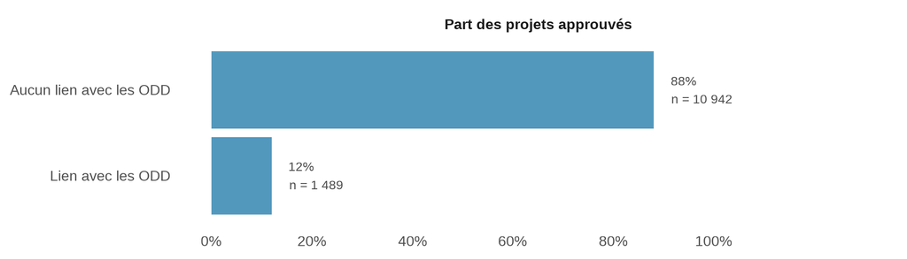

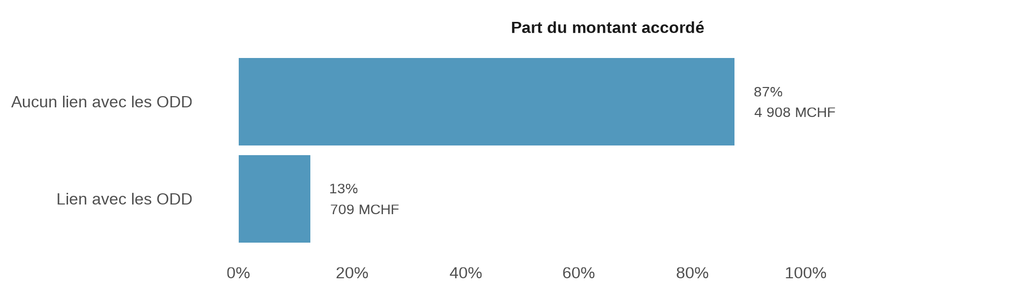

Données : projets approuvés de 2016 à 2021.

Projets approuvés de 2016 à 2021 pour lesquels un lien avec un ou plusieurs ODD a été établi (part des projets et part du montant accordé)

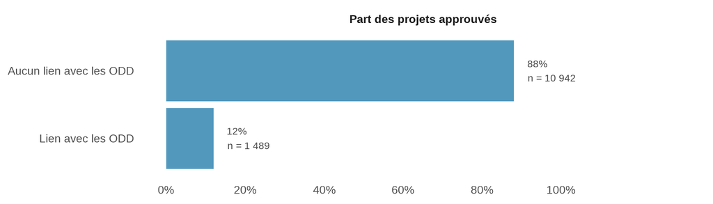

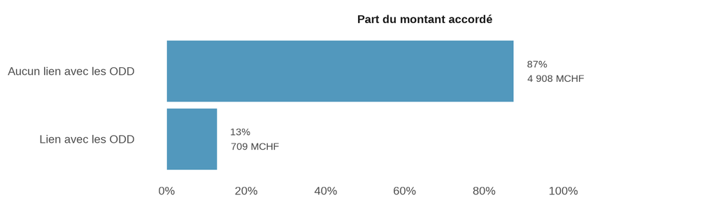

Données : projets approuvés de 2016 à 2021.

Une légère tendance à la hausse se dessine depuis 2016 : d’après l’approche retenue, les projets approuvés en lien avec les ODD sont toujours plus nombreux, ce qui implique davantage de moyens financiers consacrés à la recherche sur ces objectifs de développement durable. Aucune différence notable ne se dégage entre les différents domaines de recherche (sciences humaines et sociales : SHS ; mathématiques, sciences naturelles et ingénierie : MINT ; sciences de la vie : SV).

Évolution de la proportion de projets approuvés de 2016 à 2021 pour lesquels un lien avec un ou plusieurs ODD a été établi (part des projets et part du montant accordé)

[interactive chart not shown]

Données : projets approuvés de 2016 à 2021.

Évolution de la proportion de projets approuvés de 2016 à 2021 pour lesquels un lien avec un ou plusieurs ODD a été établi (part des projets et part du montant accordé)

[interactive chart not shown]

Données : projets approuvés de 2016 à 2021.

### Le climat et la santé : thèmes de recherche les plus représentés

L’approche retenue a permis de déterminer les ODD avec lesquels les projets approuvés par le FNS présentaient un lien. Les six ODD suivants ont été identifiés le plus fréquemment :

- ODD 13 : Mesures relatives à la lutte contre les changements climatiques (3,1 % des projets analysés)
- ODD 3 : Bonne santé et bien-être (3,1 %)
- ODD 7 : Énergie propre et d’un coût abordable (1,9 %)
- ODD 16 : Paix, justice et institutions efficaces (1,7 %)
- ODD 10 : Inégalités réduites (0,5 %)
- ODD 11 : Villes et communautés durables (0,4 %)

Nombre de projets approuvés entre 2016 et 2021 par ODD

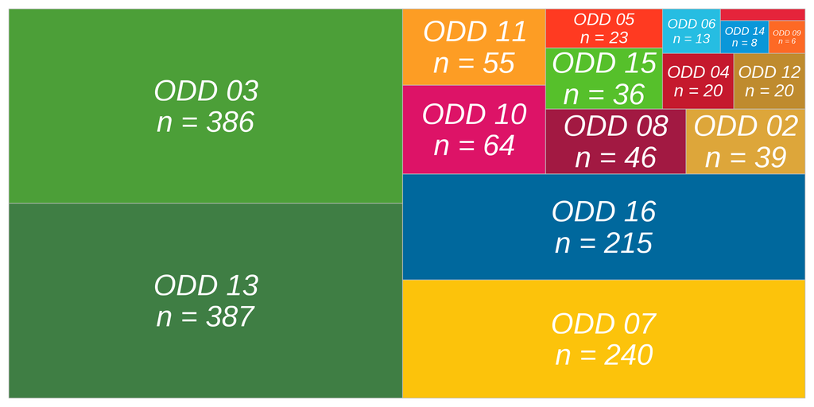

Données : projets approuvés de 2016 à 2021.

Nombre de projets approuvés entre 2016 et 2021 par ODD

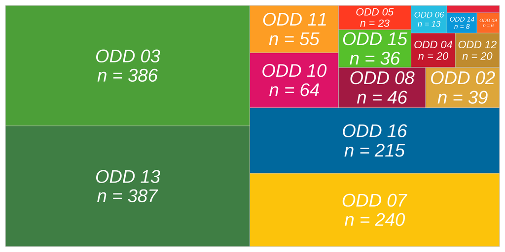

Données : projets approuvés de 2016 à 2021.

Quels domaines de recherche se consacrent à ces ODD ? Si pour les trois ODD les plus fréquemment identifiés, un domaine de recherche particulier se dégage nettement, les deux autres domaines contribuent eux aussi à approfondir les thèmes traités. Les thèmes de l’ODD 16 (Paix, justice et institutions efficaces) et de l’ODD 10 (Inégalités réduites) sont abordés quasi exclusivement par les disciplines des sciences humaines et sociales (SHS). En revanche, l’ODD 11 (Villes et communautés durables) se retrouve dans des proportions similaires dans les sciences humaines et sociales et les disciplines MINT (mathématiques, sciences naturelles et ingénierie), les sciences de la vie (SV) jouant également un rôle moindre.

Contribution des trois domaines de recherche au six ODD les plus fréquemment identifiés

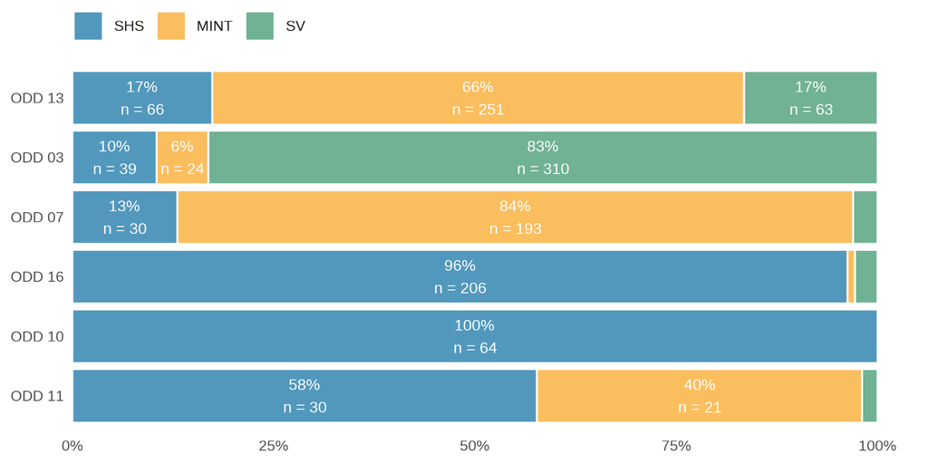

Données : projets approuvés de 2016 à 2021.

Contribution des trois domaines de recherche au six ODD les plus fréquemment identifiés

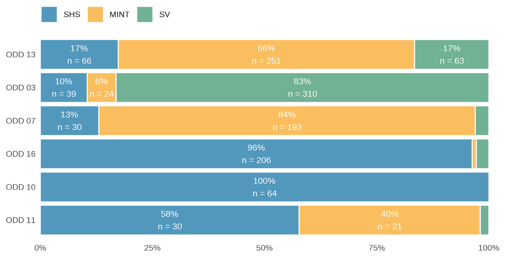

Données : projets approuvés de 2016 à 2021.

### Recherche en faveur d’une énergie propre et d’un coût abordable : plusieurs disciplines impliquées

Nous abordons ci-après avec l’ODD 7 (énergie propre et d’un coût abordable), un thème d’une grande actualité. Pour 240 projets approuvés – soit 1,9 % de ceux analysés et l’équivalent de 108 millions de francs de subsides –, l’approche retenue a établi un lien avec cet ODD.

Près de la moitié des projets approuvés (44 %) sont des projets qui impliquent plusieurs disciplines. Ce constat vaut aussi pour les autres ODD : 47 % des projets approuvés en lien avec un ODD impliquent également plusieurs disciplines. À titre de comparaison : parmi tous les autres projets financés par le FNS, seuls 41 % impliquent plus d’une discipline. Cette observation soutient la [thèse](https://www.nature.com/articles/525315a) selon laquelle un renforcement de la collaboration au-delà des frontières disciplinaires permettrait de mieux faire face aux défis globaux auxquels nous sommes confrontés : les problématiques complexes requièrent la coopération, l’établissement de consensus, des processus de validation, l’échange et l’approfondissement fructueux d’idées et une communication efficace qui dépasse les frontières disciplinaires.

Nombre de disciplines impliquées dans les projets approuvés pour lesquels un lien avec l’ODD 7 (énergie propre et d’un coût abordable) a été établi

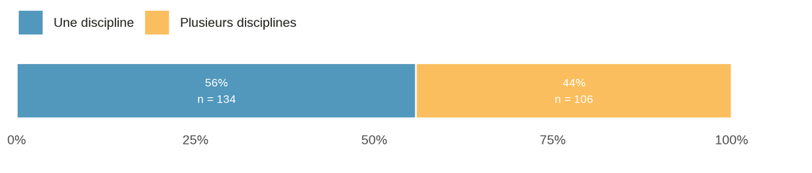

Données : projets approuvés de 2016 à 2021 présentant un lien avec l’ODD 7.

Nombre de disciplines impliquées dans les projets approuvés pour lesquels un lien avec l’ODD 7 (énergie propre et d’un coût abordable) a été établi

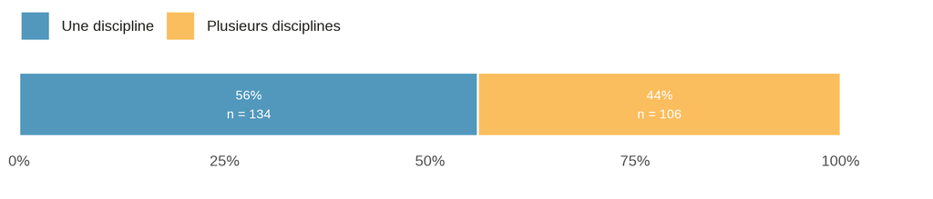

Données : projets approuvés de 2016 à 2021 présentant un lien avec l’ODD 7.

Parmi les projets approuvés ayant un lien avec l’ODD 7, la combinaison des disciplines suivantes est la plus fréquente :

- chimie et sciences de l’ingénieur (46 projets, 43 % de projets approuvés associés à plusieurs disciplines) ;
- physique et sciences de l’ingénieur (15 projets, 14 %) ;
- chimie et physique (13 projets, 12 %).

Souvent, ces projets impliquent la collaboration d’au moins deux requérant·es. Dans le cas des projets associés à l’ODD 7, 23 % sont de nature collaborative ; un taux que l’on recense à l’échelle de l’ensemble des projets ayant un lien avec un ODD. Sur l’ensemble des projets du FNS, la proportion de projets collaboratifs n’est que de 19 %.

Degré de collaboration au sein des projets approuvés de 2016 à 2021 pour lesquels un lien avec l’ODD 7 (énergie abordable et propre) a été établi

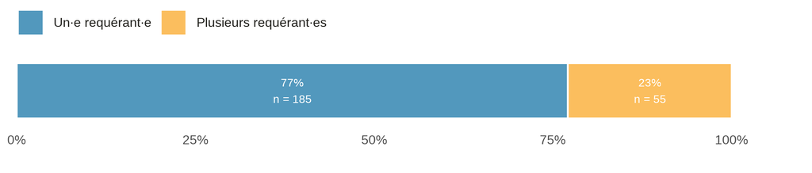

Données : projets approuvés de 2016 à 2021 présentant un lien avec l’ODD 7.

Degré de collaboration au sein des projets approuvés de 2016 à 2021 pour lesquels un lien avec l’ODD 7 (énergie abordable et propre) a été établi

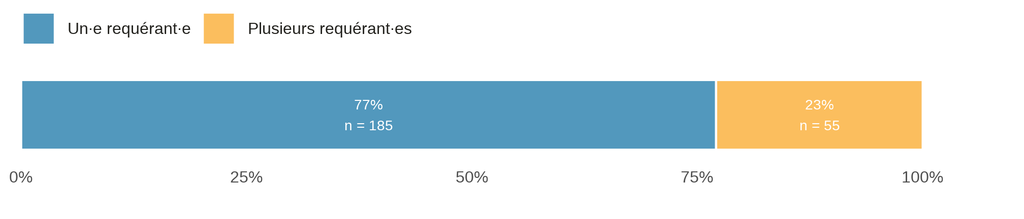

Données : projets approuvés de 2016 à 2021 présentant un lien avec l’ODD 7.

Le nombre de requérant·es impliqué·es dans les 55 projets collaboratifs identifiés dans le cadre de l’ODD 7 est de 152. Le partenariat entre institutions suisses et étrangères, tel qu’on le recense dans 28 projets, constitue la forme de collaboration la plus répandue.

### 2023 : enquête sur les ODD

Comme mentionné plus haut, les outil de classification utilisés dans l’approche retenue sont toujours en cours de perfectionnement. Il nous est dès lors impossible, à l’heure actuelle, d’affirmer avec certitude combien de projets approuvés présentent effectivement un lien avec les ODD. Afin de disposer de données plus fiables et plus détaillées, le FNS lancera, en 2023, une enquête auprès de requérant·es de projets approuvés portant sur la contribution concrète de leurs travaux aux ODD. L’objectif est de permettre d’examiner la recherche du FNS sous une perspective plus systématique et de mettre en lumière les lacunes des connaissances actuelles en matière de développement durable. Au moyen d’initiatives ciblées, nous pourrons alors lancer des projets visant à combler ces lacunes et, par conséquent, soutenir la réalisation des ODD.

### Données

Ce récit de données repose sur l’analyse des titres, résumés et mots-clés des projets approuvés de la période 2016-2021 ayant abouti à une allocation de fonds de recherche. Ont été exclus de l’analyse les projets approuvés soutenant la communication scientifique, c.-à-d. les instruments Agora, Scientific Exchanges, publications de livres en Open Access, ainsi que les subsides de publication. En raison de leur structure différente, les Pôles de recherche nationaux (PRN) n’ont également pas été pris en considération. L’analyse a porté sur un total de 12’431 projets.

L’identification des **projets approuvés impliquant plusieurs disciplines** s’est fondée sur les données fournies par les requérant·es lors de la soumission (voir les disciplines principales et secondaires selon la [liste des disciplines du FNS](https://www.snf.ch/SiteCollectionDocuments/allg_disziplinenliste.pdf)). Cette liste se décline en trois niveaux : le premier niveau se compose des trois domaines de recherche : sciences humaines et sociales (SHS), mathématiques, informatique, sciences naturelles et ingénierie (MINT) et sciences de la vie (SV). Les deuxième et troisième niveaux sont, quant à eux, une subdivision et un approfondissement des domaines ou disciplines du niveau supérieur. Dès lors qu’un projet comporte au moins deux disciplines du deuxième niveau, il est considéré comme impliquant plusieurs disciplines.

Par **projets collaboratifs**, on entend les travaux de recherche menés conjointement par deux requérant·es ou plus : ces projets impliquent donc, en plus du ou de la requérant·e chargé·e de la correspondance, au moins un·e requérant·e supplémentaire.

**Informations complémentaires**

[Développement durable](https://www.snf.ch/fr/3DEoAgSx2yMXZaAX/dossier/developpement-durable)

Les données, le texte et le code de ce récit de données sont [disponibles sur Github](https://github.com/snsf-data/datastory_snf_research_and_sdgs) et [archivés sur Zenodo](https://doi.org/10.46446/datastory.snf-research-and-sdgs).  
DOI: 10.46446/datastory.snf-research-and-sdgs

[^1]: Wastl J, Hook DW, Fane B, Draux H, Porter SJ. 2020. Contextualizing Sustainable Development Research. Using Dimensions to explore the global landscape of research on Sustainable Development Goals. Digital Science. Report. https://doi.org/10.6084/m9.figshare.12200081.v2
[^2]: Wulff DU, Meier DS, Mata R. 2023. Using novel data and ensemble models to improve automated labeling of Sustainable Development Goals. Preprint: https://arxiv.org/pdf/2301.11353.pdf